# Domain Analysis of Email Addresses

In this document, I parse the email list of Ready for R participants, and try to map those with a country top level domain to the countries to produce a choropleth of where Ready for R participants are from.

```r
knitr::opts_chunk$set(warning=FALSE, message=FALSE)
suppressMessages({library(readr)
library(janitor)
library(dplyr)
library(tldextract)
library(ggplot2)
library(forcats)
library(urltools)
  })


email_addresses <- read_csv("tinyletter_contacts_2020_10_15.csv") %>%
  clean_names()
```

Extract the very top level domain from tlds like `co.uk` by using `tidyr::separate_rows` to separate on `.`. Now that I think about it, this is probably introducing lots of `.co` domains, so I need to fix this.

Update: ended up using `gsub()` on the `tld` column to extract the country code.

```r
tld_names <- getTLD()

tlds <- tldextract(email_addresses$e_mail)  %>%
     mutate(tld=  gsub("[a-z]+\\.", "", tld))
```

As a first pass, I scrape the country level domains from https://www.countries-ofthe-world.com/TLD-list.html I tried multiple other CSV files from other courses, but this is the only source I could find with domain names mapped to countries.

```r
library(rvest)
library(stringr)
country_page <- xml2::read_html("https://www.countries-ofthe-world.com/TLD-list.html")

countries <- bind_rows(html_table(country_page)) %>%
  janitor::clean_names()

countries <- countries %>%
  filter(grepl("\\.", domain)) %>%
  mutate(tld = str_remove(domain, "^\\."))
```

Map the email domains to countries using `left_join()`. Count by country.

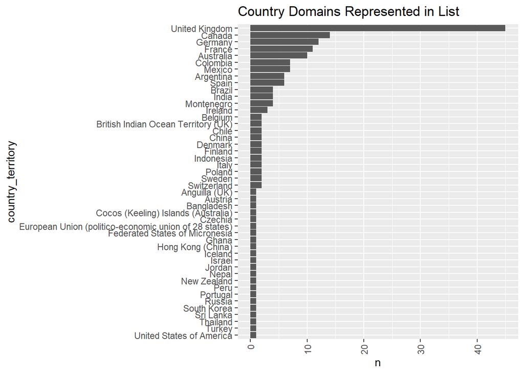

```r
tld_counts <- tlds %>%
  filter(tld != "com") %>%
  filter(tld != "edu") %>%
  filter(tld != "org") %>%
  left_join(y= countries, by=c("tld"="tld")) %>%
  count(country_territory, tld) %>%
  arrange(desc(n)) %>%
  mutate(country_territory = fct_reorder(country_territory, desc(n))) %>% ungroup() %>% mutate(country_territory = fct_rev(country_territory)) %>%
  tidyr::drop_na(country_territory)

ggplot(tld_counts) +
  aes(x=country_territory, y=n) +
  geom_bar(stat = "identity") +
  theme(axis.text.x = element_text(angle=90, hjust = 1, vjust=0.5)) +
  ggtitle("Country Domains Represented in List") +
  coord_flip()
```

Use `choroplethr::country_choropleth()` to display country counts. Data is still pretty dirty, this is a first pass.

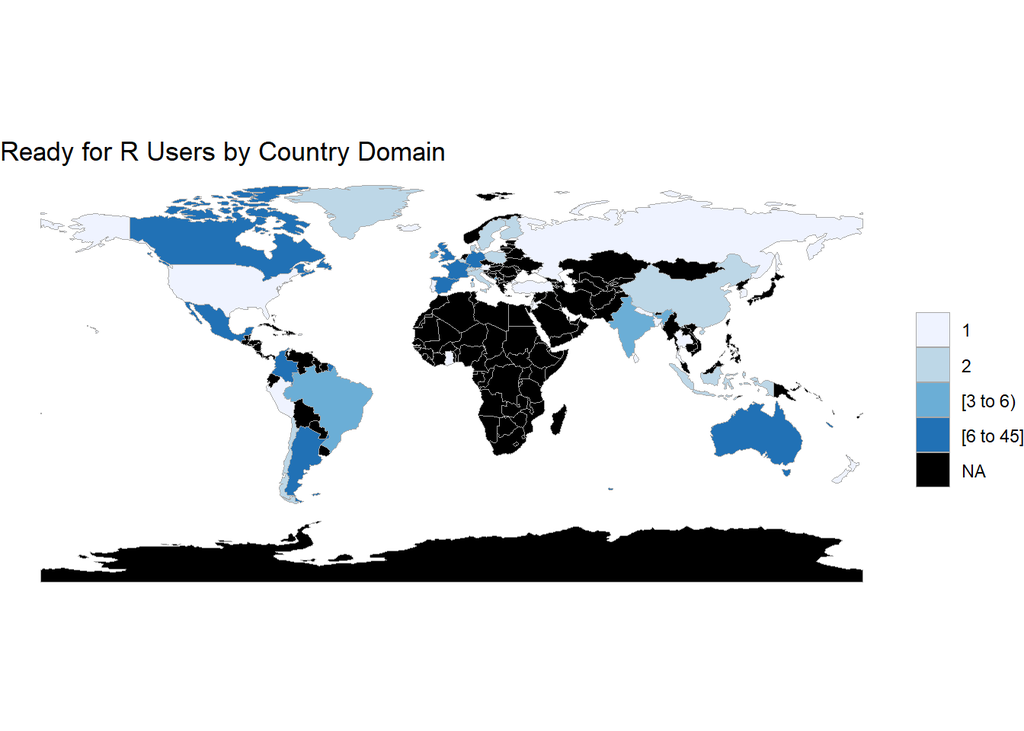

```r
library(choroplethr)
library(choroplethrMaps)

tld_counts %>%
  mutate(country_territory = tolower(country_territory)) %>%
  select(region=country_territory, value=n) %>%
  country_choropleth(title="Ready for R Users by Country Domain",num_colors = 4)
```

Look at the top level domains by frequency count. As expected, `.com` and `.edu` dominate the list.

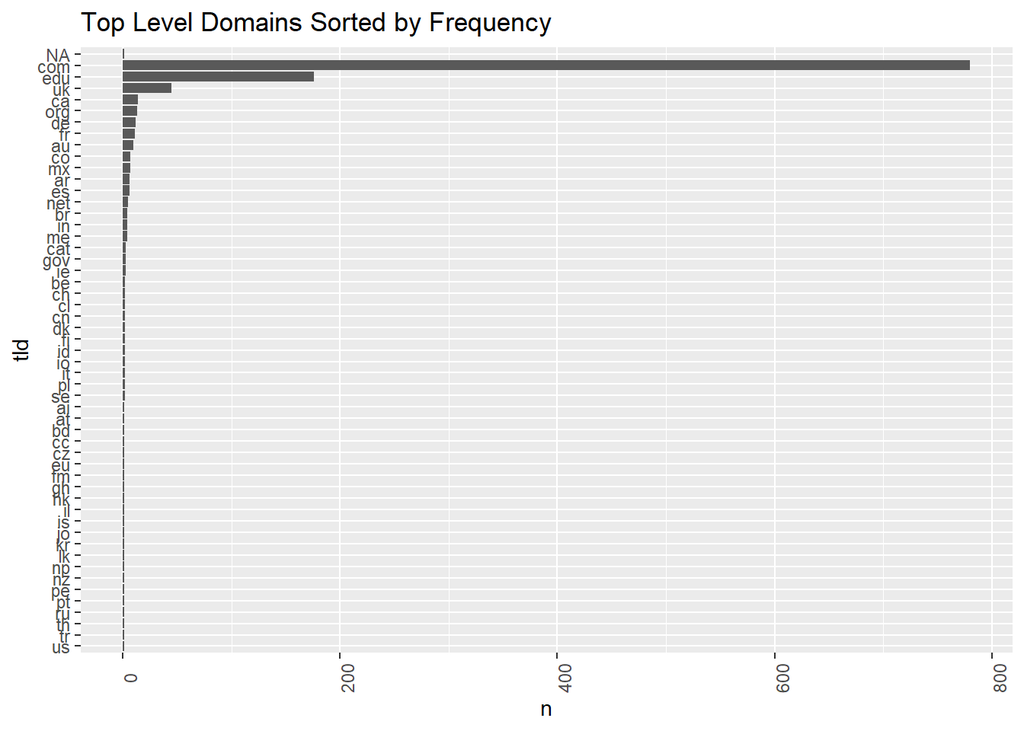

```r
tlds %>%
  mutate(tld = factor(tld)) %>%
  count(tld) %>%
  arrange(desc(n)) %>%
  mutate(tld = fct_reorder(tld, desc(n))) %>%
  mutate(tld = fct_rev(tld)) %>%
  ggplot() +
  aes(x=tld, y=n) +
  geom_bar(stat = "identity") +
  theme(axis.text.x = element_text(angle=90)) +
  labs(title="Top Level Domains Sorted by Frequency")+ coord_flip()
```

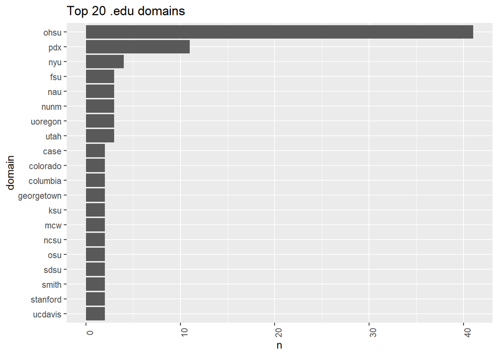

```r
tlds %>%
  filter(grepl("edu", tld)) %>%
  tidyr::separate(domain, into
                  =c("email", "domain"), sep="@")  %>%
  tidyr::drop_na(domain) %>%
  count(domain) %>%
  arrange(desc(n)) %>%
  slice(1:20) %>%
   mutate(domain = fct_reorder(domain, desc(n))) %>%
  mutate(domain = fct_rev(domain)) %>%
  ggplot() +
  aes(x=domain, y=n) +
  geom_bar(stat = "identity") +
  theme(axis.text.x = element_text(angle=90)) +
  labs(title="Top 20 .edu domains") +
  coord_flip()
```

# How Many OHSU folks?

```r
tlds %>%
  filter(grepl("ohsu", domain)) %>%
  nrow()
```

```
## [1] 42
```